# Intro to markdown

Ryan

October 1, 2015

# Markdown Introduction

> Markdown is a lightweight markup language with plain text formatting syntax designed so that it can be converted to HTML – [wikipedia](https://en.wikipedia.org/wiki/Markdown)

Markdown uses different symbols to mark headers:

# Header Level 1

## Header Level 2

### Header Level 3

make things **BOLD** or *italic*

create a link  
[This is a link](http://www.example.com)

add a picture

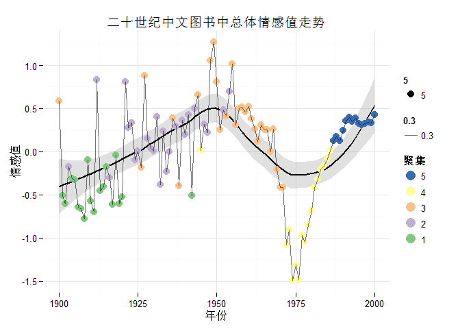

add a footnote[^1]

add a code block

```
@requires_authorization
def somefunc(param1='', param2=0):
    '''A docstring'''
    if param1 > param2: # interesting
        print 'Greater'
    return (param2 - param1 + 1) or None
class SomeClass:
    pass
>>> message = '''interpreter
... prompt'''
```

a quote

> 常识是十八岁之前在头脑中所铺下的偏见层 – 忘记是谁说的了

My favourite LaTeX Formula

- Inline formula example: $\Gamma(n) = (n-1)!\quad\forall n\in\mathbb N$
- Block formula example: $x = \dfrac{-b \pm \sqrt{b^2 - 4ac}}{2a}$

Table made easy

| Item | Value | Qty |
| --- | --- | --- |
| Computer | 1600 USD | 5 |
| Phone | 12 USD | 12 |
| Pipe | 1 USD | 234 |

## See Markdown Quick Reference for more

So what R Markdown have to offer?

inline r code evaluation

The average miles per gallon is 20.090625 in our dataset

or r code chunck

```r
summary(mtcars$mpg)
```

```
##    Min. 1st Qu.  Median    Mean 3rd Qu.    Max.
##   10.40   15.42   19.20   20.09   22.80   33.90
```

plot

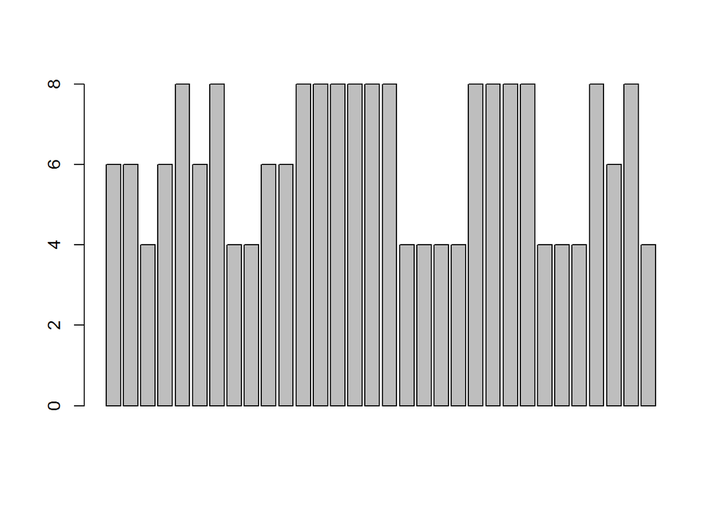

```r
barplot(mtcars$cyl)
```

try knit this document to generate documents of the format that you want  
…you need to install it first

## more chuck options

R code not evaluated , setting `eval = F`

```r
install.packages("rmarkdown")
```

Hide the r code but display the result using `echo = F`

```
## [1] 0.3333333
```

Hide only part of the code `echo = c()`

```r
print(a/b)
```

```
## [1] 0.3333333
```

```r
print("Can you see this?")
```

```
## [1] "Can you see this?"
```

Message by default will shown

```
## stat_bin: binwidth defaulted to range/30. Use 'binwidth = x' to adjust this.
```

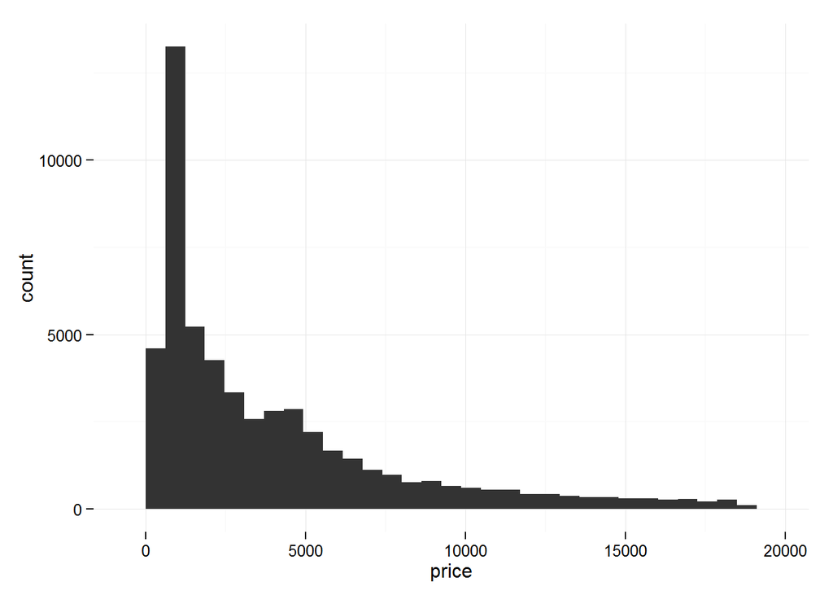

```r
qplot(x = price, data = diamonds)
```

suppress by setting `message = F`

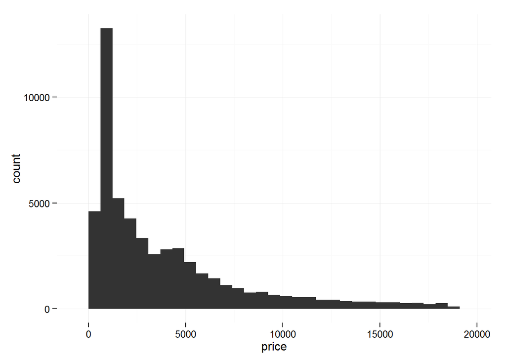

```r
qplot(x = price, data = diamonds)
```

there could be warnings as well…

```
## Warning: Removed 8421 rows containing missing values (geom_point).
```

```
## Warning: Removed 13642 rows containing missing values (geom_point).
```

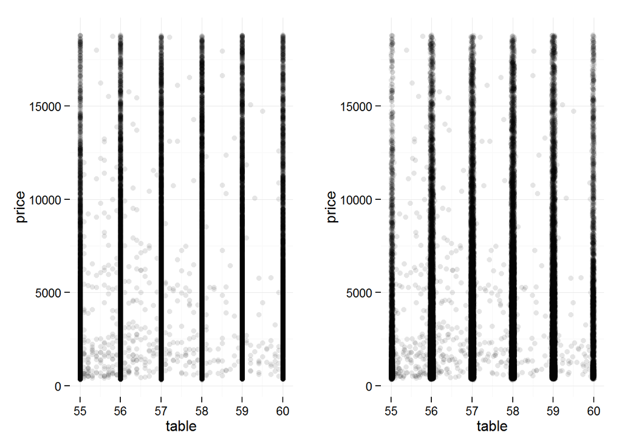

```r
p1 <- ggplot(aes(x= table , y = price), data = diamonds) +
    geom_point(alpha = 0.1) +
    xlim(55,60)
p2 <- ggplot(aes(x= table , y = price), data = diamonds) +
    geom_jitter(alpha = 0.1) +
    xlim(55,60)
grid.arrange(p1,p2, ncol = 2)
```

get rid of it by setting `waring = F`

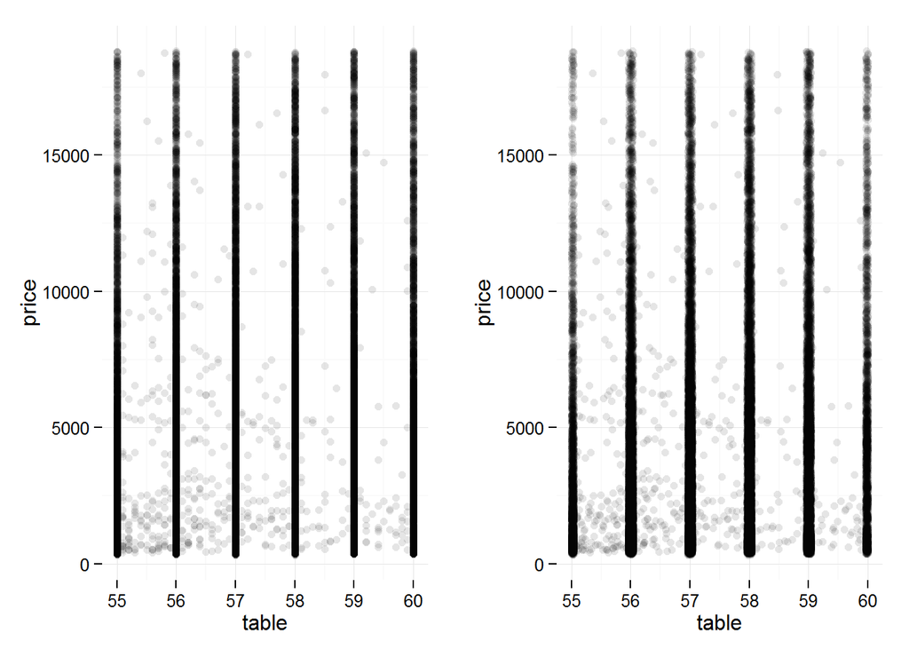

```r
p1 <- ggplot(aes(x= table , y = price), data = diamonds) +
    geom_point(alpha = 0.1) +
    xlim(55,60)
p2 <- ggplot(aes(x= table , y = price), data = diamonds) +
    geom_jitter(alpha = 0.1) +
    xlim(55,60)
grid.arrange(p1,p2, ncol = 2)
```

You can cache the chunk that requires large amount of computation by `cache = T`  
This is not that slow, but we only work with 1/10 of the dataset, if you try the full dataset or use ntreeTry of larger values… it is going to be SLOW….

```r
library(randomForest)
set.seed(123)
pick <- sample(1:nrow(diamonds), size = nrow(diamonds)/10, replace = F)
X = diamonds[pick, -7]
Y = diamonds$price[pick]
tuneRF(x = X, y = Y)
```

```
## mtry = 3  OOB error = 508881.7
## Searching left ...
## mtry = 2     OOB error = 608380.4
## -0.1955244 0.05
## Searching right ...
## mtry = 6     OOB error = 437976.3
## 0.1393356 0.05
## mtry = 9     OOB error = 418858.5
## 0.04365023 0.05
```

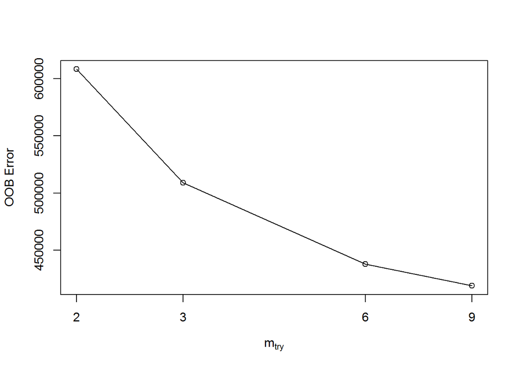

```
##   mtry OOBError
## 2    2 608380.4
## 3    3 508881.7
## 6    6 437976.3
## 9    9 418858.5
```

This is even slower… You don’t want to try this… even on 1/10 of the diamonds dataset

```r
result <- rfcv(trainx = X,
               trainy = Y,
               cv.fold= 5,
               step = 3)
```

If we do this on the entire dataset, we shall push the button and go home, come back to see result tomorrow.

```r
set.seed(0306)
RFModel <- randomForest(x = X,
                        y = Y,
                        mtry = 6,
                        importance = T,
                        proximity = F)
RFModel$importance
```

```
##             %IncMSE IncNodePurity
## carat    8314560.38   21980179338
## cut        21235.29     166611132
## color    1078929.43    2283716075
## clarity  2053404.66    4549672796
## depth      24628.49     354046238
## table      16757.71     219485840
## x        2824632.78   11206070193
## y       13258166.37   39857859442
## z         559685.01    1898682964
```

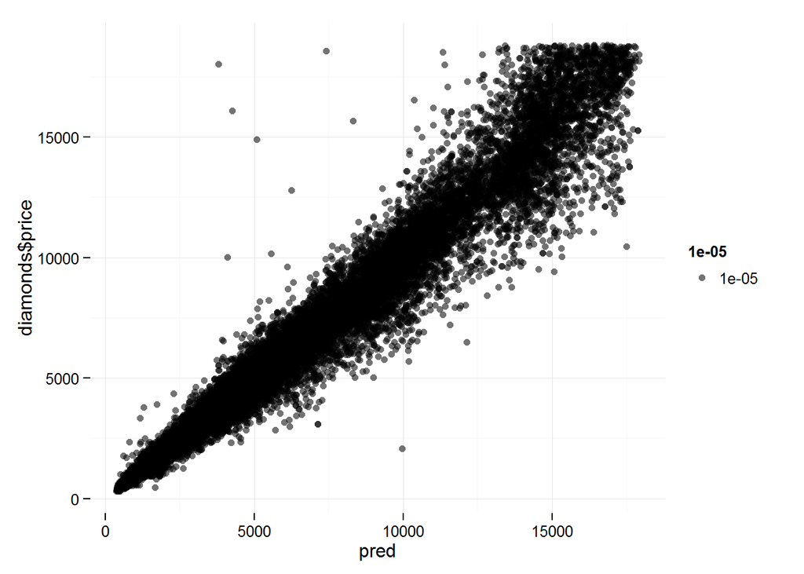

```r
pred <- predict(RFModel, diamonds[,-7])
qplot(x = pred, y = diamonds$price, alpha = 0.00001)
```

[^1]: This is a demo footnote